# R Notebook

## Assignment 2

Model #1: Use Age as a predictor for Price

```r
library(readr)
UsedCarLot <- read_csv("C:/Users/zguan/Downloads/UsedCarLot.csv")
View(UsedCarLot)
head(UsedCarLot, n=100)
```

| year | price | mileage | model | make |
| --- | --- | --- | --- | --- |
| 2014 | 21.450 | 50.070 | 328 | BMW |
| 2014 | 29.888 | 30.717 | 328 | BMW |
| 2014 | 22.988 | 36.824 | 328 | BMW |
| 2016 | 27.950 | 8.575 | 328 | BMW |
| 2009 | 11.888 | 139.088 | 328 | BMW |
| 2008 | 8.999 | 100.000 | 328 | BMW |
| 2013 | 15.997 | 77.585 | 328 | BMW |
| 2015 | 20.900 | 45.802 | 328 | BMW |
| 2015 | 25.997 | 30.915 | 328 | BMW |
| 2012 | 19.988 | 45.940 | 328 | BMW |

[output cut: 90 more lines]

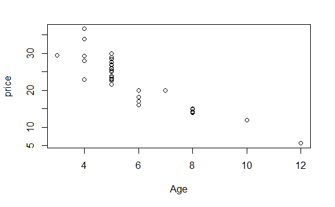

```r
library(dplyr)
set.seed(500) #Enter any number here
BMWCar = sample_n(subset(UsedCarLot, model=="328"), 40)
BMWCar$Age = 2019-BMWCar$year
plot(price~Age, data = BMWCar)
```

```r
mod1 = lm(price~Age, data = BMWCar)
```

## 1.

```r
mod1 = lm(formula = price ~ Age, data = BMWCar)
print(mod1)
```

```
Call:
lm(formula = price ~ Age, data = BMWCar)

Coefficients:
(Intercept)          Age
     40.967       -3.178
```

The equation is $Price = 40.967 - 3.178*Age$

## 2.

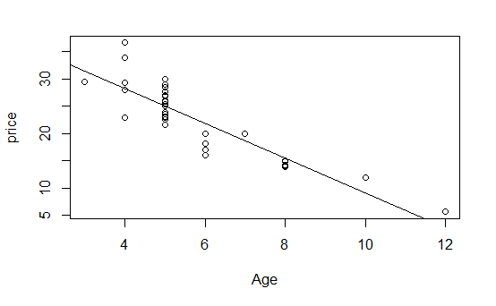

```r
plot(price~Age, data = BMWCar)
mod1 = lm(price~Age, data = BMWCar)
abline(mod1)
```

## 3. Residuals Plot: Produce appropriate residual plots and comment on how well your data appear to fit the conditions for a simple linear model. Don’t worry about doing transformations at this point if there are problems with the conditions.

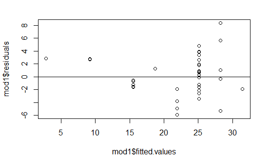

```r
plot(mod1$residuals ~ mod1$fitted.values)
abline(0,0)
```

In the residuals for the price and age of the car, the linear model does not seem to be an appropriate fit for simple linear model. It is not randomly dispersed and has a clear pattern.

```r
resid(mod1)
```

```
          1           2           3           4           5           6           7           8           9          10          11          12          13
 1.03315358 -1.54249479 -2.58175851 -0.27384642  3.90324149 -0.07675851 -3.42075851 -0.66349479 -3.79967060  8.34515358  0.70124149 -1.89967060  0.80324149
         14          15          16          17          18          19          20          21          22          23          24          25          26
-4.91667060  1.80324149  2.86885685 -1.93293433  3.42324149  4.82124149 -5.27384642 -5.90167060  5.62515358 -2.08875851  3.82324149 -1.56249479 -1.56749479
         27          28          29          30          31          32          33          34          35          36          37          38          39
-1.24449479 -4.89867060 -2.09675851  1.26741730  2.70168103  0.27924149  2.62224149 -0.55449479  0.91124149 -1.57675851 -1.22075851  2.78568103 -0.54749479
         40
 1.92324149
```

## 4.

```r
summary(mod1)
```

```
Call:
lm(formula = price ~ Age, data = BMWCar)

Residuals:
    Min      1Q  Median      3Q     Max
-5.9017 -1.9080 -0.4107  2.0980  8.3452

Coefficients:
            Estimate Std. Error t value Pr(>|t|)
(Intercept)  40.9672     1.6497   24.83  < 2e-16 ***
Age          -3.1781     0.2642  -12.03 1.58e-14 ***
---
Signif. codes:  0 *** 0.001 ** 0.01 * 0.05 . 0.1   1

Residual standard error: 3.169 on 38 degrees of freedom
Multiple R-squared:  0.7921,    Adjusted R-squared:  0.7866
F-statistic: 144.7 on 1 and 38 DF,  p-value: 1.578e-14
```

```r
resMod = subset(BMWCar, mod1$residuals == max(abs(mod1$residuals)))
```

Max residual by magnitude is 8.34154 at point 10, which is a car that is a four year old BMW from 2015, with 24,779 miles and has a value of around $36,600.

```r
match(c(36.6), UsedCarLot$price)
```

```
[1] 65
```

```r
rstandard(mod1)[10]
```

```
      10
2.703912
```

```r
rstudent(mod1)[10]
```

```
      10
2.968952
```

## 5.

```r
confint(mod1, level = 0.9)
```

```
                  5 %      95 %
(Intercept) 38.185862 43.748535
Age         -3.623458 -2.732718
```

```r
test<-lm(BMWCar$price~BMWCar$Age)
summary(test)
```

```
Call:
lm(formula = BMWCar$price ~ BMWCar$Age)

Residuals:
    Min      1Q  Median      3Q     Max
-5.9017 -1.9080 -0.4107  2.0980  8.3452

Coefficients:
            Estimate Std. Error t value Pr(>|t|)
(Intercept)  40.9672     1.6497   24.83  < 2e-16 ***
BMWCar$Age   -3.1781     0.2642  -12.03 1.58e-14 ***
---
Signif. codes:  0 *** 0.001 ** 0.01 * 0.05 . 0.1   1

Residual standard error: 3.169 on 38 degrees of freedom
Multiple R-squared:  0.7921,    Adjusted R-squared:  0.7866
F-statistic: 144.7 on 1 and 38 DF,  p-value: 1.578e-14
```